# Part I - (Factors that affect Borrower's Application for Prosper Loan )

## by (Adeola Adebanjo-IndigoFalcon)

## Investigation Overview

> The aim of this analysis is to find out the factors that affect Borrower's application for prosperLoan. Thorough explanation on these factors will be seen in the slides below.

## Dataset Overview

> The prosperLoan data set was chosen for this exporatory analysis. It had a total of 113,937 loans with 81 variables on each loan, including loan amount, borrower rate (or interest rate), current loan status, borrower income, and many others. Most of the variables in this dataset are numeric in nature. The categorical data in this dataset are Loan Status, Closed Date, Prosper rating(numeric), Prosper rating(Alpha), among a few others. A total of 14 colums were chosen for effective visualisation in other to be able to provide adequeate insights and they are; **LoanStatus,BorrowerAPR,BorrowerRate, ProsperRating (numeric), BorrowerState, EmploymentStatus,EmploymentStatusDuration,IsBorrowerHomeowner CreditScoreRangeLower, CreditScoreRangeUpper, DebtToIncomeRatio,IncomeRange,StatedMonthlyIncome,LoanOriginalAmount** After thorough analysis the following insights were seen as discussed below.

# **(Distribution of Debt to Income Ratio)**

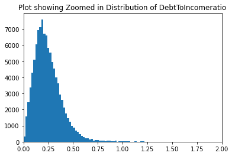

# (Distribution of Employment Status Duration)

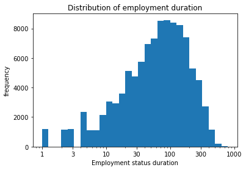

# (Distribution of Original Amount Being Borrowed)

### Here we can see that there are spikes in the density of the LoanOriginalAmount Borrowed with the highest peaking above 0.00012.

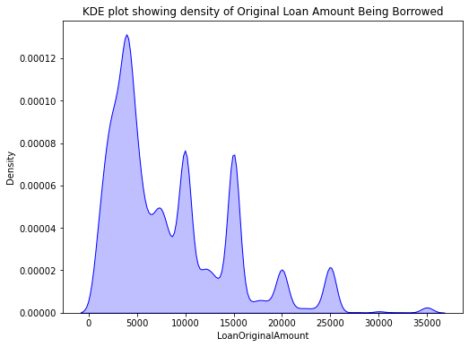

# (Distribution of Employment Status)

### From this Analysis we see that, for the Employment status we had a high level of employed individuals. A highest number of individuals considered for loans were employed. A very small number of people given loan were unemployed

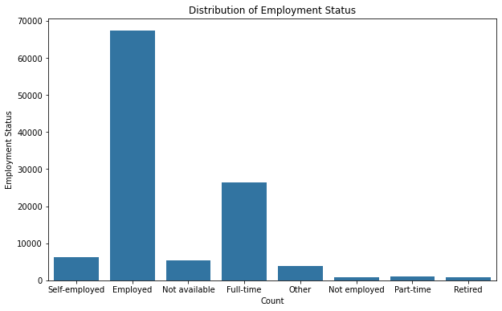

# (Distribution of Borrowers' Credit Score Range)

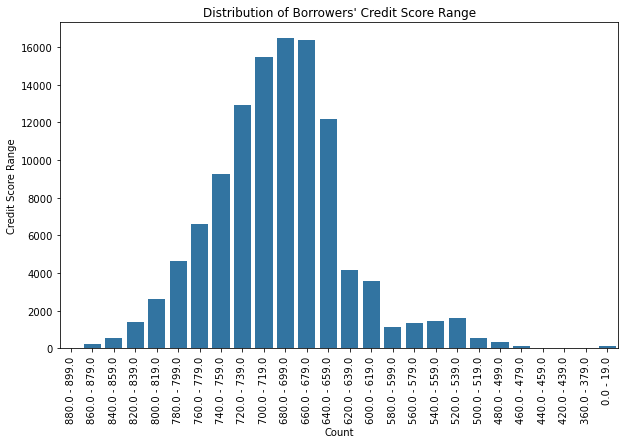

# (Employment Status Compared with various variables(Loan Original Amount, Debt to Income ratio and Borrower's rate )

### Comparing the LoanOriginalAmount, DebtToIncomeRatio and BorrowerRate to EmploymentStatus,

### we can see that throughout the violin plot of the LoanOriginalAmount to Employment Status, there is a spike in the amount being borrowed showing that all categories had a spike at about the 5000.

### Comparing the DebtToIncomeRatio toEmploymentStatus,we can see a lot of spike, that is outliers up to the 1o.o mark on the y-axis

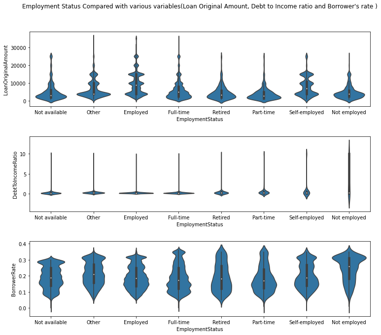

# (Scatter plot of Loan Original Amount to Borrower's Rate)

### The higher the borrower rate, the less ther number of individual borrowers and the lower the amount being borrowed

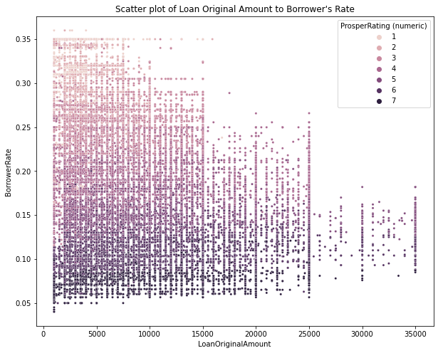

# (Multiset Bar Chart of Employment Status to stated Monthly income)

### We also see that the borrowers witht the highest income are selfemployed and are homeowners.

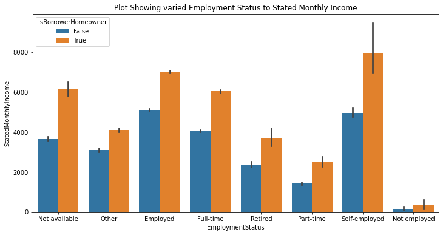